# MTH6139 Time Series

Analysing Petrol Prices Over Time in the UK

Kenich Pandeya

13 March 2024

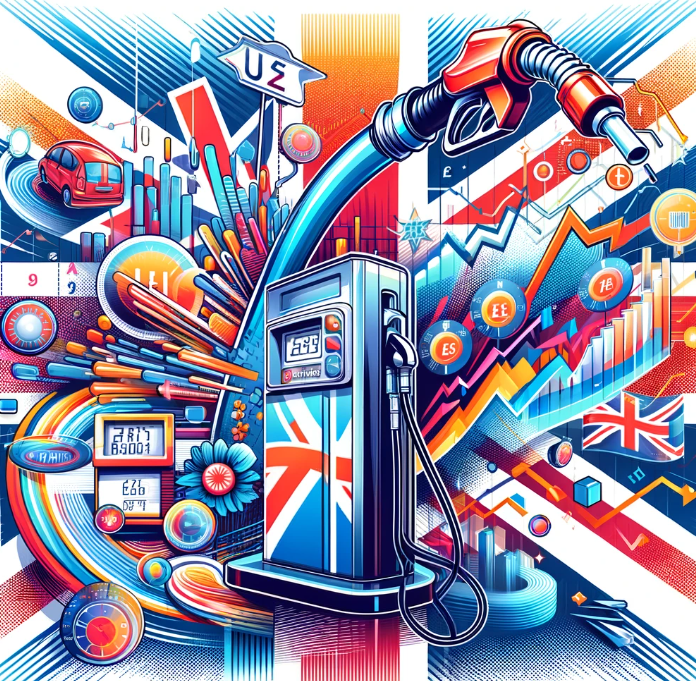

# Analysing Petrol Prices in the UK Over Time Using Prophet

This project explores Petrol price dynamics using time series analysis techniques. The data used for this analysis is downloaded from [UK’s Government Data Page](https://www.gov.uk/government/statistics/weekly-road-fuel-prices) and I will be using the price of Unleaded Petrol for my analysis. I, then extracted data for Petrol in another file and saved it as a csv file. The petrol prices in this data is based on the average UK pump prices from six companies and recorded weekly. This data starts from June 2003. The prices in the data set is in terms of pence. (£1=100p)

## Objective of this project

By analysing this dataset, the main objective of this project is to seek to understand the patterns and trends of Petrol prices in the UK over time, and ultimately to forecast the price of Petrol in the UK next year. I will be using Meta’s Prophet library to model the data.

## 1.Setting up the Data

In this chapter, we will deal with setting up the library, loading the data into R, and for defining our dataframe.

### 1.1 Set up the library

I would like to first load the prophet in my library. To load it a simple R-code has been written down:

```r
library(prophet)
```

Prophet is a forecasting tool developed by Meta, which is designed to simplify time series forecasting tasks. This will help us in analysing the components of the price of Petrol over time and also forecast the future prices .

### 1.2 Loading the data into the R

Now, we try to load the data in the system.

```r
fuel_data<-read.csv("C:/Users/pkeni/OneDrive - Queen Mary, University of London/Petrol Price UK .csv")
```

Now that I have loaded the data into R my next step would be converting it into dataframe of prices and volumes. I am making sure that the data reads through so I have converted them into Date and numeric form so that prophet is able to fit it. Initially, I will also look at weekly seasonality of the data as I want to identify recurring patterns to exhibit distinct petrol price movements. Also, as the prices are recorded on a weekly basis, I believe weekly seasonality would work the best in this terms.

```r
fuel_data$date<-as.Date(fuel_data$Date)
fuel_data$Price<-as.numeric(fuel_data$Price)
petrol_price <-data.frame(
  ds=zoo::as.Date(fuel_data$Date),
  y=fuel_data$Price)
```

## 2. Historic Data Analysis

In this chapter, we look at the historic data and analyse it.

### 2.1 Visualising the Petrol Price Data

In this section, I will simply just plot the petrol price solely based in its historic price.

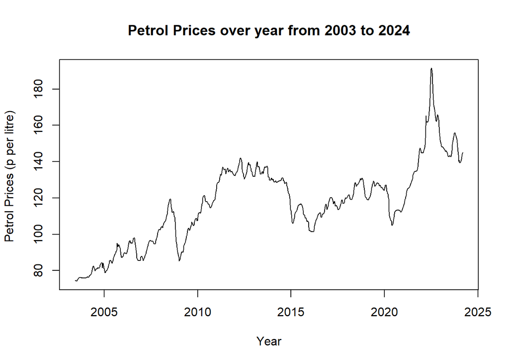

```r
plot(petrol_price$ds,petrol_price$y, main="Petrol Prices over year from 2003 to 2024", xlab="Year",ylab="Petrol Prices (p per litre) ",type="l")
```

The historical data suggests that the petrol prices show a rising trend throughout the years with significant volatility. It shows a notably sharp rise and fall of prices between 2020 and 2025, which shows significant volatility in recent years.

### 2.2 Decomposing the Time Series Data

Now to further examine the time series, we tend to decompose the data. As the data was loaded manually in R, I had some problem in decomposing it to look at the trend, seasonality, cyclic patterns and residual noise in the data. So, to decompose the data, I first convert it into a Time Series Using function **ts()**. As I know that the original data starts from 09 June 2003, I start the data from the very date and as it is weekly I set the frequency of the Time Series to be 52.

```r
fuel_data_ts<-ts(fuel_data$Price,start=c(2003,06,09),frequency=52)
```

As the time series “fuel_data_ts” has been defined, now I decompose the time series to see how it performs.

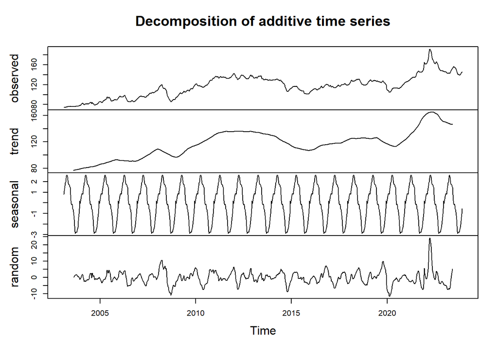

```r
plot(decompose(fuel_data_ts))
```

*Note: I have only used the fuel_data_ts here as it is transformed into Time Series data type in R, in the other sections, i will be using the petrol_price data frame which I particularly defined for prophet, as it has the recorded date from the dataset for consistency and accuracy.*

### 2.3 Fitting Linear Trend Function to the Time Series

I, now, will run a linear regression which will help me gain understanding of the growth of the petrol prices in the UK. Here, I will use the **lm** function.

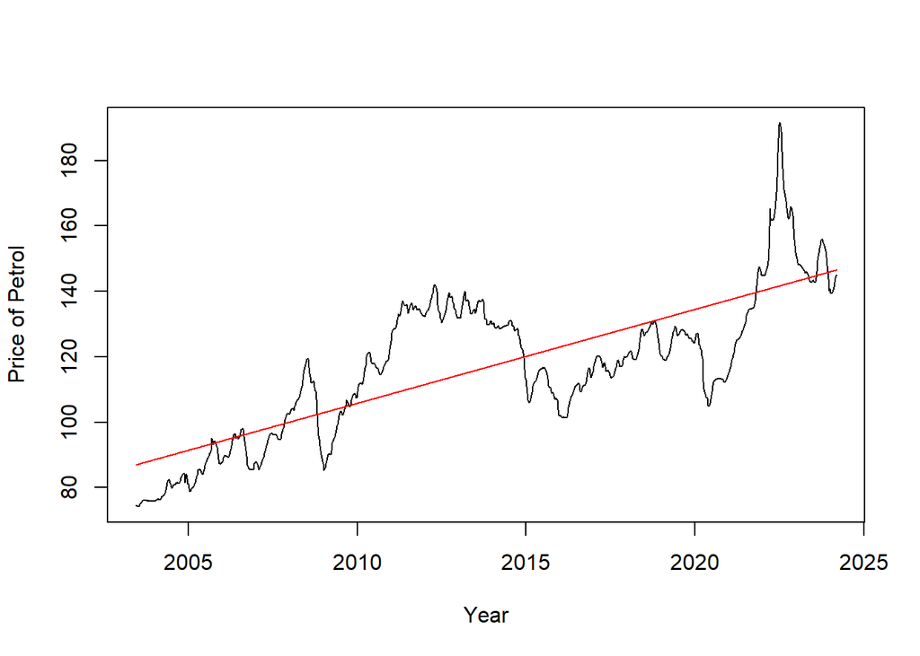

```r
plot(petrol_price$ds,petrol_price$y, type='l', xlab='Year', ylab='Price of Petrol', main='')
Linearmodel_fuel=lm(petrol_price$y~petrol_price$ds,petrol_price)
lines(petrol_price$ds,fitted(Linearmodel_fuel), type="l", col='red')
```

The trend line suggests an upward trend in the fuel price data. It also suggests volatile fluctuations in the prices which peaks around 2020-2022.

```r
summary(Linearmodel_fuel)
```

```
##
## Call:
## lm(formula = petrol_price$y ~ petrol_price$ds, data = petrol_price)
##
## Residuals:
##     Min      1Q  Median      3Q     Max
## -30.741 -10.246  -3.642  10.395  49.887
##
## Coefficients:
##                   Estimate Std. Error t value Pr(>|t|)
## (Intercept)     -9.0597428  3.1404207  -2.885  0.00399 **
## petrol_price$ds  0.0078596  0.0001944  40.423  < 2e-16 ***
## ---
## Signif. codes:  0 '***' 0.001 '**' 0.01 '*' 0.05 '.' 0.1 ' ' 1
##
## Residual standard error: 14.02 on 1082 degrees of freedom
## Multiple R-squared:  0.6016, Adjusted R-squared:  0.6013
## F-statistic:  1634 on 1 and 1082 DF,  p-value: < 2.2e-16
```

It is evident that the Residual Standard Error is 14.02, which means that the model is in average 14.02 pence off while using this to predict the fuel price. The multiple R squared value of 60.16% suggests that the 60.16% of variability in the petrol prices can be explained by the time in this model.

## 3. Using Prophet to Model the Petrol Prices

In this chapter, I use prophet to fit the petrol prices, and forecast the future petrol prices in the UK.

### 3.1 Fitting the Data into Prophet Model

Now, I will fit the data frame (petrol.prices) into prophet to analyse the data. This prophet function is used to fit the model. I won’t use daily and weekly seasonality as this data has been recorded weekly, as it won’t have clear predictions for each day of the week.

```r
model_price=prophet::prophet(petrol_price,weekly.seasonality = FALSE)
```

```
## Disabling daily seasonality. Run prophet with daily.seasonality=TRUE to override this.
```

The prophet model is an additive model with components such as trend, seasonality, holidays and error terms.

### 3.2 Future Price Data Frame Setup

Now that the model has been fitted using the prophet function, the predictions are made on the dataframe, using the funtion **make_future_dataframe**, this function takes the model object and a number of periods to forecast to provide a suitable dataframe of the dates.

```r
future_price<-make_future_dataframe(model_price,periods=52,freq="week")
tail(future_price)
```

```
##              ds
## 1131 2025-02-03
## 1132 2025-02-10
## 1133 2025-02-17
## 1134 2025-02-24
## 1135 2025-03-03
## 1136 2025-03-10
```

As, this project is based on a weekly dataset, the future predictions are based will also be on weekly forecast for better accuracy, so I have set the frequency to week. Here, the data frame is set such that it is ready to forecast fuel prices weekly up-to a year.

### 3.3 Forecasting the Future Prices

As the new data frame has been defined in chapter 3.2, here I will use the dataframe defined to make future predictions of petrol prices. For this I will use the function **predict**. This function is responsible to make predictions from the results of different model fitting functions.

```r
predict_futureprice=predict(model_price,future_price)
tail(predict_futureprice[c('ds','yhat','yhat_lower','yhat_upper')])
```

```
##              ds     yhat yhat_lower yhat_upper
## 1131 2025-02-03 164.8891   154.9531   176.1460
## 1132 2025-02-10 165.1761   155.2985   175.8518
## 1133 2025-02-17 165.4674   153.7546   175.8201
## 1134 2025-02-24 165.8712   154.8216   175.6661
## 1135 2025-03-03 166.5093   155.8947   176.5015
## 1136 2025-03-10 167.3507   156.6929   177.7257
```

### 3.4 Visualising the Forecast

Now, the forecast made in section 3.3 can be visualised using Dygraphs, which is an interactive plot of the future predictions.

```r
library(dygraphs)
dyplot.prophet(model_price,predict_futureprice)
```

[interactive chart not shown]

In the graph above, the X-axis denotes time in years, whereas the Y- axis denotes the petrol prices per litre in pence. It is evident that Prophet has been able to explain the variability in the data most of the time, as the actual data points mostly fall within the confidence interval bounds of predicted petrol prices. But, in some instances such as in extreme values, the model wasn’t able to explain the variations. These extreme values are generally cause by external factors, for instance, the petrol prices in 2022 was heavily impacted because of the Russia Ukraine war - which caused major energy crisis in the United Kingdom, leading to the rapid acceleration in the price of petrol. The model also predicts that the prices of petrol will not reach towards its all time maximum in 2022 in the upcoming year.

### 3.5 Further Examinations

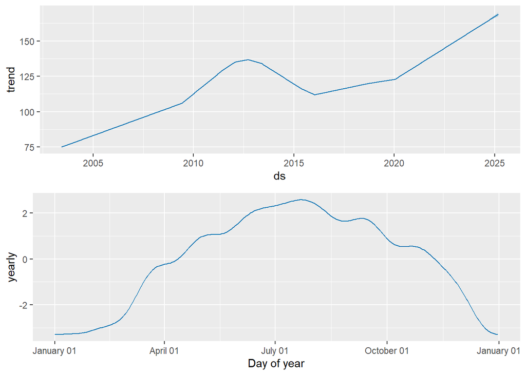

```r
prophet_plot_components(model_price,predict_futureprice)
```

The yearly seasonality data suggests that the prices are usually higher usually from May to November. This suggests that the fuel prices typically increase during summer, which is logical, as people more often travel during this time, especially with holidays and road trips during these months, which tend to increase the demand of petrol, which results in increasing price of petrol.

## 4. Conclusion

This project has utilised Prophet to analyse and forecast the Petrol Prices in the UK, which revealed a general upward trend through years. The forecast indicates a continued rise in petrol prices over the next year. It also shows the particular higher prices in fuel throughout the summer as anticipated.

Even though, the model captures the overall trends and seasonality, incorporating other economic and external factors would definitely enhance the accuracy. This analysis will generally help assists the stakeholders in planning and decision-making with the fluctuating fuel costs.